```python
from sklearn.pipeline import Pipeline, FeatureUnion
from sklearn.preprocessing import OneHotEncoder
from sklearn.grid_search import GridSearchCV
import datetime, dill, gzip, simplejson, pickle
from sklearn.metrics import r2_score, mean_squared_error, mean_absolute_error
from sklearn.ensemble import RandomForestRegressor, ExtraTreesRegressor
from sklearn.cluster import KMeans
import pylab as pylab
import pandas as pd
import numpy as np
import matplotlib.pylab as plt
import seaborn as sns
import matplotlib
%matplotlib inline
matplotlib.rcParams['savefig.dpi'] = 2 * matplotlib.rcParams['savefig.dpi']
```

# The Problem

The ultimate subway dilemma. You arrive at a station that has both local and express trains. A local train just arrived. Should you hop on or wait for the express train?

To solve this problem, we are going to simplify it greatly by only optimizing for time between express stations. There are several factors that one considers beyond just travel time (e.g. having a seat, over-crowding, smells), but those will be discarded for this analysis.

# Importing and formatting data

Raw data: http://web.mta.info/developers/data/nyct/historic/A%20Division%20Historical%20Data%20May%202011.zip

Documentation: http://web.mta.info/developers/data/nyct/historic/A%20Division%20Historical%20Data%20Documentation.txt

GTFS schedule data: http://web.mta.info/developers/data/nyct/subway/google_transit.zip

The raw data comes as a collection of data from each day. These need to be combined into a single pandas DataFrame, which we will call 'data.' It comes with a timestamp but needs to be converted to datetime and set as the index.

Each train trip has a unique id that are reused each day, so to get the service number, we need to combine the service date with the train id to get the service number - a unique identifier for a single trip on a single day.

Finally, we import the stops from the GTFS schedule data to merge with 'data' and get stop names.

```python
may = []

for x in range(1,9):
    may.append(pd.read_csv('mtahistorical/historical_data/ATS-Data_2011-05-0' + str(x) + '.csv'))
for x in range(10,32):
    may.append(pd.read_csv('mtahistorical/historical_data/ATS-Data_2011-05-' + str(x) + '.csv'))
data= pd.concat(may)
data.dropna()

data['timestamp'] = [ datetime.datetime.strptime(x, '%Y-%m-%d %H:%M:%S') for x in data['timestamp']]
data = data.set_index('timestamp')

data['service'] = data['service_date'] + data['train_id']

stops = pd.read_csv('google_transit/stops.txt')
data['stop_id'] = data['stop_id'].astype(str)
data = data.merge(stops, on='stop_id', how='left')

len(data)
```

```
3614694
```

The raw data contains 3.6+ million events: both arrivals and departures at every stop for all lines that are collected. An average rider only cares about the time from one train arriving until arriving at the next station. The time between arrival and departure is just additional wait time for the rider. So, all departure times are discarded.

Furthermore, we need to separate the data into the appropriate line: red (1,2,3) and green (4,5,6).

```python
red = data [ (data['route_id'] <= 3) & (data['event_type'] == 1) ]
green = data [ (data['route_id'] > 3) & (data['event_type'] == 1) ]
```

# Processing the data

Now that the data is loaded, it needs to be processed for each line. Riders do not care what time a train comes. They care about how long it takes between stops. The data is processed to collect the difference in timestamps between stop.

The function below discards everything but the express stops for the selected line. Then the data is transformed for the relevant data for each service (train_id/date combo).

Please note, that an artificial cutoff of 15 minutes per station is included to remove extended delays from rare events.

```python
def dx_color(train,color):
    unique = train['service'].unique()
    line = train['route_id'].values[0]
    if color  in 'red':
        usestops = ['Chambers St', '14 St', '34 St - Penn Station', 'Times Sq - 42 St', '72 St', '96 St']
    else:
        usestops = ['Brooklyn Bridge - City Hall', '14 St - Union Sq', 'Grand Central - 42 St', '59 St', '86 St', '125 St']

    expstop = []
    for x in train['stop_name']:
        if x in usestops:
            expstop.append(True)
        else:
            expstop.append(False)

    train = train[expstop].sort(['service'])


    start = []
    stop = []
    startnum = []
    stopnum = []
    duration = []
    timestamp = []
    stoplat = []
    stoplon = []
    weekday = []
    hour = []
    route = []
    direction = []
    service = []
    train_id = []
    minute = []
    second = []
    for x in unique:
        df = train[ train[ 'service' ] == x]
        if len(df) > 1:
            df = df.sort_index()
            direct = df['direction_id'].values
            trainstops = df['stop_name'].values
            times = df.index
            services = df['service'].values

            for t in np.arange( len( df ) ):
                for b in range(t, len( df ) ):
                    if not t == b:

                        cstop = usestops.index(trainstops[t])
                        nstop = usestops.index(trainstops[b])

                        if (times[b] - times[t]).seconds/60. < 15*abs(nstop - cstop):
                            start.append(trainstops[t])
                            stop.append(trainstops[b])

                            startnum.append(cstop)
                            stopnum.append(nstop)

                            duration.append((times[b] - times[t]).seconds/60.)
                            timestamp.append(times[t])
                            stoplat.append(df['stop_lat'].values[t])
                            stoplon.append(df['stop_lon'].values[t])
                            weekday.append(times[t].weekday())
                            hour.append(times[t].hour)
                            direction.append(direct[t])
                            route.append(df['route_id'].values[t])
                            service.append(services[t])
                            train_id.append(df['train_id'].values[t])
                            minute.append(times[t].minute)
                            second.append(times[t].second)

    test = pd.DataFrame({
            'timestamp': timestamp,
            'weekday' : weekday,
            'hour': hour,
            'start': start,
            'stop': stop,
            'duration': duration,
            'stop_lat': stoplat,
            'stop_lon': stoplon,
            'direction': direction,
            'route':route,
            'startnum':startnum,
            'stopnum':stopnum,
            'service':service,
            'train_id': train_id,
            'minute' : minute,
            'second' : second
    })
    return test
```

```python
# Preprocessed data
reddata = dill.load(  open( "mta_redtest2.p", "rb" ) )
greendata = dill.load( open( "mta_greentest2.p", "rb" ) )
```

```python
len(reddata) + len(greendata)
```

```
830124
```

# Distribution

The distributions of the data by train and direction for each station could be modeled with a Poisson process. However, for several express lines (most notably 2 and 3), there is a second distribution for when the express trains run local (see below).

```python
def distro( color, start, stop): #color, direction, station number
    i = 0
    labels = ["1 (Local)", "2 (Express)", "3 (Express)"]
    if color['route'].values[0] > 3:
        i = 3
        labels = ["4 (Express)", "5 (Express)", "6 (Local)"]

    x = color[(color['startnum'] == start) &(color['stopnum'] == stop)][['route','duration','startnum','start','stop']]
    x1 = x[ (x['route'] == (1+i) ) ]['duration']
    x2 = x[ (x['route'] == (2+i) ) ]['duration']
    x3 = x[ (x['route'] == (3+i) ) ]['duration']
    names = x[['start','stop']]


    graph = [x1,x2,x3]


#     plt.xlabel('Train')
    plt.ylabel('Duration in Minutes')
    plt.title(names['start'].values[0] +" to "+ names['stop'].values[0])
    sns.violinplot(graph, color="pastel", names=labels)
```

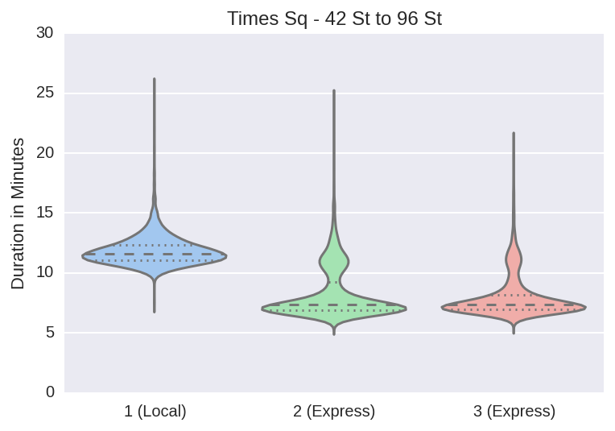

```python
distro(reddata, 3,5)
```

# The Model

I used an Extra Random Forest Regressor with bootstrapping as the main component of my model. Using a grid search, the optimum parameters were found.

Because all of the input is categorical data (route, starting station, ending station, day of the week, and hour), everything went through a One Hot Encoder before the extra random forest.

```python
# redtest = dill.load(  open( "mta_redtest2.p", "rb" ) )


rx = redtest[['route','startnum', 'stopnum', 'weekday','hour']]
ry = redtest['duration']

rX_train, rX_test, ry_train, ry_test = cross_validation.train_test_split(rx, ry, test_size=0.3, random_state=42)

pipe = Pipeline([
        ('enc', OneHotEncoder()),
        ('pred', ExtraTreesRegressor(bootstrap=True, criterion='mse', max_depth=30,
          max_features='auto', max_leaf_nodes=None, min_samples_leaf=11,
          min_samples_split=12, min_weight_fraction_leaf=0.0,
          n_estimators=10, n_jobs=-1, oob_score=False, random_state=42,
          verbose=0, warm_start=True))
    ])

rm = pipe
rm.fit(rX_train,ry_train)

# dill.dump( rm, open( "mta_redmodel2.p", "wb" ) )
# dill.dump( (rX_test, ry_test), open( "mta_redtestdata2.p", "wb" ) )
```

# Feature Importance

```python
redmodel = dill.load( open( "mta_redmodel2.p", "rb" ) )

rm = redmodel
imp = rm.get_params().get('pred').feature_importances_
ind = rm.get_params().get('enc').feature_indices_
feats = ['Route','Starting Station', 'Ending Station','Weekday','Hour']
feat = {}
for w in np.arange(len(feats)):
    feat[feats[w]] = imp[ind[w]:ind[w+1]]
redweight = pd.DataFrame(pd.Series({ p:sum(feat[p]) for p in feat}, name = 'Red Feature Weight').order(ascending=False) )
redweight
```

|  | Red Feature Weight |
| --- | --- |
| Starting Station | 0.457196 |
| Ending Station | 0.330907 |
| Route | 0.170900 |
| Hour | 0.024899 |
| Weekday | 0.016098 |

```python
greenmodel = dill.load( open( "mta_greenmodel2.p", "rb" ) )
gm = greenmodel
imp = gm.get_params().get('pred').feature_importances_
ind = gm.get_params().get('enc').feature_indices_
feats = ['Route','Starting Station', 'Ending Station','Weekday','Hour']
feat = {}
for w in np.arange(len(feats)):
    feat[feats[w]] = imp[ind[w]:ind[w+1]]
greenweight = pd.DataFrame(pd.Series({ p:sum(feat[p]) for p in feat}, name = 'Green Feature Weight').order(ascending=False) )
greenweight
```

|  | Green Feature Weight |
| --- | --- |
| Starting Station | 0.420816 |
| Route | 0.358188 |
| Ending Station | 0.188063 |
| Weekday | 0.017095 |
| Hour | 0.015839 |

# How did the model do?

The pearson correlation for observed and predicted withheld test data is 0.96 for the red model and 0.97 for the green model.

```python
rX_test, ry_test = dill.load( open( "mta_redtestdata2.p", "rb" ) )
gX_test, gy_test = dill.load( open( "mta_greentestdata2.p", "rb" ) )

print 'Red MSE: ' + str(mean_squared_error(ry_test,redmodel.predict(rX_test)))
print 'Green MSE: ' + str(mean_squared_error(gy_test,greenmodel.predict(gX_test)))
```

```
Red MSE: 2.43420802523
Green MSE: 3.08942993909
```

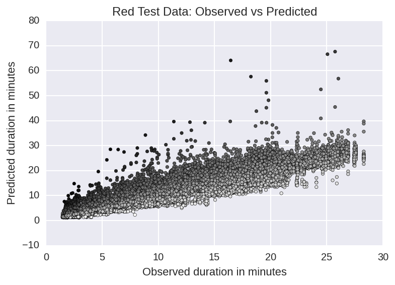

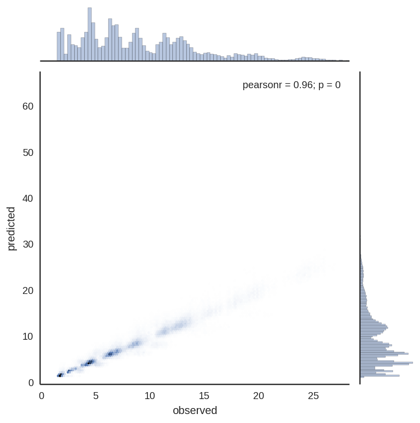

```python
graph(ry_test, redmodel.predict(rX_test),'Red')
```

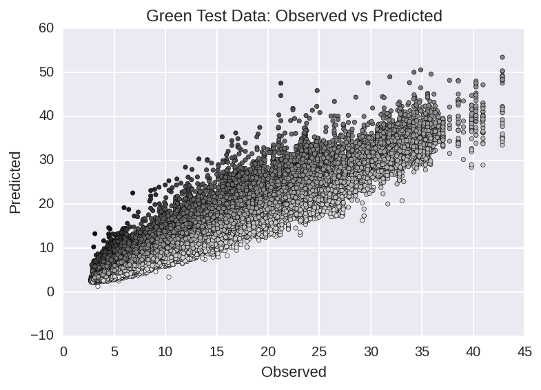

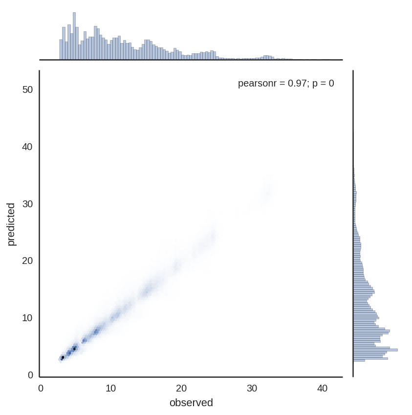

```python
graph(gy_test, greenmodel.predict(gX_test),'Green')
```

```python
def graph(y,x,name):
    tmp = pd.DataFrame({
            'predicted':y,
            'observed':x
        })
    Y = tmp['predicted']
    X = tmp['observed']


    T = np.arctan2(Y, X)

    plt.ylabel('Predicted duration in minutes')
    plt.xlabel('Observed duration in minutes')
    plt.title(name+' Test Data: Observed vs Predicted')

    plt.scatter(X, Y, s=10, c=T, alpha=1)

    with sns.axes_style("white"):
        sns.jointplot(X, Y, kind="hex");
```

# Implementing the model in Flask

The web app first scraps the MTA status page to make sure there is "Good Service." If not, the user is informed about what kind of service disruption is occurring and to check the MTA status page for more information.

Assuming good service, the subway line, direction, and applicable model are determined from the starting and stopping stations. The user is informed if these inputs are either the same station or not on the same line.

```python
def predict(start, stop):
    url = 'http://web.mta.info/status/serviceStatus.txt'
    raw_page = urllib2.urlopen(url).read()

    soup = BeautifulSoup(raw_page)
    lines = soup.find('subway').select('line')
    start = request.form['start']
    stop = request.form['stop']
    t = datetime.datetime.now()
    day = t.weekday()
    hour = t.hour
    minute = t.minute
    sec = t.second

    red = ['Chambers St', '14 St', '34 St - Penn Station', 'Times Sq - 42 St', '72 St', '96 St']
    green = ['Brooklyn Bridge - City Hall', '14 St - Union Sq', 'Grand Central - 42 St', '59 St', '86 St', '125 St']

    if start in red and stop in red:
        l = [1,2,3]
        stops = red
        model = dill.load( open( "mta_redmodel2.p", "rb" ) )
        stat  = '123'

    elif start in green and stop in green:
        l = [6,5,4]
        stops = green
        model = gm
        stat = '456'
    else:
        flash("Are you sure you are on the right line?")
        return redirect(url_for('show_entries'))

    cstart = stops.index(start)
    cstop = stops.index(stop)

    if start == stop:
        flash ("Are you sure you are going somewhere?")
        return redirect(url_for('show_entries'))

    for x in lines:
        if x.find('name').text == stat:
            status = x.find('status').text
            if status == 'PLANNED WORK':
                flash( "Check the status! There's planned work!" )
                return redirect(url_for('show_entries'))
            elif status == 'SERVICE CHANGE':
                flash ( "Check the status! There's a service change!" )
                return redirect(url_for('show_entries'))
            elif status == 'DELAYS':
                flash ( "Take what you can get, there's a delay right now." )
                return redirect(url_for('show_entries'))
            else:

                local = model.predict([l[0],cstart,cstop,day,hour])
                exp1 = model.predict([l[1],cstart,cstop,day,hour])
                exp2 = model.predict([l[2],cstart,cstop,day,hour])

                answer = round(float(local - min( exp1, exp2) ), 1)
                if exp1 > exp2:
                    fast = "   The fastest train is the "+str(l[1])+" train."
                else:
                    fast = "   The fastest train is the "+str(l[2])+" train."

                intro = "From "+start+" to "+stop+":\n"
                wait = " Take the local unless the next express train is less than "+ str(answer) + " minutes away.\n"

                message = intro+wait+fast
                flash( message )
                return redirect(url_for('show_entries'))
```

# What's next and limitations?

Current real-time testing of the models using the MTA's live data feed to further validate the model.

The user interface is confusing and not as beautiful or intuitive as it can be.